# Analysis of DLG2 IPMS Samples

This document details the analysis of IPMS samples using DLG2 as a bait (268 antibody). This was done across multiple Ewing sarcoma cell lines, using HOS osteosarcoma cells (isogenic clone A) as a control population (negative for DLG2).

## Setting up the environment

These are packages you will need for this notebook. For exact versions used, please refer to the session info at the bottom of this notebook.

```r
##########################################################################################
library('tidyverse')
library('ggplot2')
library('RColorBrewer')
```

I want to set a base directory that we can use as a link to the directory where we will do most of the work. I use two directories here because the Workspace is what is pushed to GitHub and contains scripts and plot files, but the Repository is where more of the big data is stored that does not get pushed.

```r
##########################################################################################
generalDatasets = 'C:/Users/chughes/Documents/bccrc/projectsRepository/generalDatasets'
baseWorkspace = 'C:/Users/chughes/Documents/bccrc/projectsWorkspace/sorensenLab/relatedToDlg2'
baseRepository = 'C:/Users/chughes/Documents/bccrc/projectsRepository/sorensenLab/relatedToDlg2'
#generalDatasets = 'C:/Users/chris/OneDrive/Documents/bccrc/projectsRepository/generalDatasets'
baseWorkspace = 'C:/Users/chris/OneDrive/Documents/bccrc/projectsWorkspace/sorensenLab/relatedToDlg2'
#baseRepository = 'C:/Users/chris/OneDrive/Documents/bccrc/projectsRepository/sorensenLab/relatedToDlg2'
```

## Data processing

Read in the ip data for A673 cells and plot.

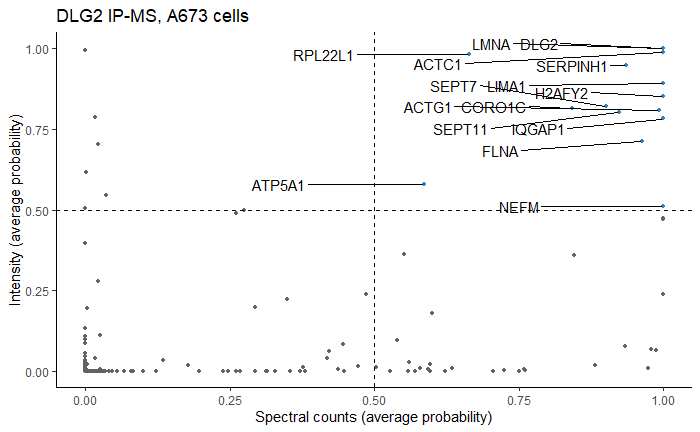

```r
##########################################################################################
spc = read_tsv(paste(baseRepository, '/proteomics20210726_dlg2IpmsEwsCells/reprintData_a673OnlySpc.tsv', sep = '')) %>%
  dplyr::select(PreyGene, AvgP, FDR) %>%
  dplyr::rename(gene = PreyGene, spc_avgP = AvgP, spc_fdr = FDR)
int = read_tsv(paste(baseRepository, '/proteomics20210726_dlg2IpmsEwsCells/reprintData_a673OnlyInt.tsv', sep = '')) %>%
  dplyr::select(PreyGene, AvgP, FDR) %>%
  dplyr::rename(gene = PreyGene, int_avgP = AvgP, int_fdr = FDR)
##
ipData = spc %>%
  left_join(int) %>%
  dplyr::mutate(pText = ifelse(spc_avgP >= 0.50 & int_avgP >= 0.50, gene, '')) %>%
  dplyr::mutate(pColor = ifelse(spc_avgP >= 0.50 & int_avgP >= 0.50, brewer.pal(3,'Blues')[3], brewer.pal(3,'Greys')[3]))
##
ggplot(ipData, aes(spc_avgP, int_avgP)) +
  geom_point(size = 1, color = ipData$pColor) +
  scale_x_continuous(limits = c(0,1), breaks = seq(0,1,0.25)) +
  scale_y_continuous(limits = c(0,1), breaks = seq(0,1,0.25)) +
  geom_text_repel(label = ipData$pText, nudge_x = -0.25, max.overlaps = 500) +
  labs(x = 'Spectral counts (average probability)', y = 'Intensity (average probability)', title = 'DLG2 IP-MS, A673 cells') +
  geom_hline(yintercept = 0.5, linetype = 'dashed') +
  geom_vline(xintercept = 0.5, linetype = 'dashed') +
  theme_classic()
ggsave(paste(baseRepository, '/proteomics20210726_dlg2IpmsEwsCells/scatter_dlg2IpmsA673OnlyPvalues.pdf',sep=''),
       height=2,width=2,useDingbats=FALSE)
```

Read in the ip data for chla10 and sknmc cells and plot.

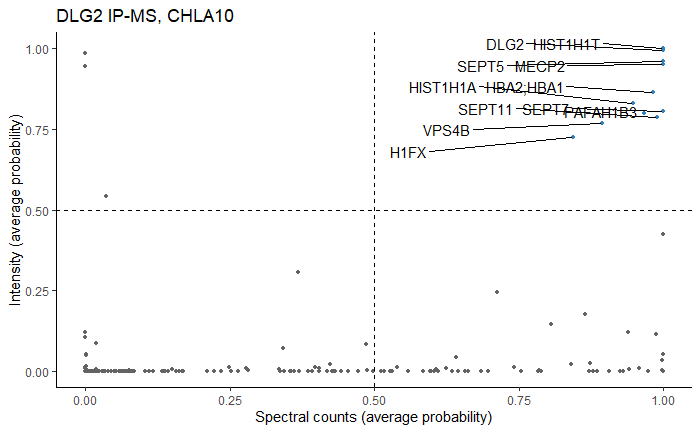

```r
##########################################################################################
spc = read_tsv(paste(baseRepository, '/proteomics20210726_dlg2IpmsEwsCells/reprintData_chla10OnlySpc.tsv', sep = '')) %>%
  dplyr::select(PreyGene, AvgP, FDR) %>%
  dplyr::rename(gene = PreyGene, spc_avgP = AvgP, spc_fdr = FDR)
int = read_tsv(paste(baseRepository, '/proteomics20210726_dlg2IpmsEwsCells/reprintData_chla10OnlyInt.tsv', sep = '')) %>%
  dplyr::select(PreyGene, AvgP, FDR) %>%
  dplyr::rename(gene = PreyGene, int_avgP = AvgP, int_fdr = FDR)
##
ipData = spc %>%
  left_join(int) %>%
  dplyr::mutate(pText = ifelse(spc_avgP >= 0.50 & int_avgP >= 0.50, gene, '')) %>%
  dplyr::mutate(pColor = ifelse(spc_avgP >= 0.50 & int_avgP >= 0.50, brewer.pal(3,'Blues')[3], brewer.pal(3,'Greys')[3]))
##
ggplot(ipData, aes(spc_avgP, int_avgP)) +
  geom_point(size = 1, color = ipData$pColor) +
  scale_x_continuous(limits = c(0,1), breaks = seq(0,1,0.25)) +
  scale_y_continuous(limits = c(0,1), breaks = seq(0,1,0.25)) +
  geom_text_repel(label = ipData$pText, nudge_x = -0.25, max.overlaps = 500) +
  labs(x = 'Spectral counts (average probability)', y = 'Intensity (average probability)', title = 'DLG2 IP-MS, CHLA10') +
  geom_hline(yintercept = 0.5, linetype = 'dashed') +
  geom_vline(xintercept = 0.5, linetype = 'dashed') +
  theme_classic()
ggsave(paste(baseRepository, '/proteomics20210726_dlg2IpmsEwsCells/scatter_dlg2IpmsChla10OnlyPvalues.pdf',sep=''),
       height=2,width=2,useDingbats=FALSE)
```

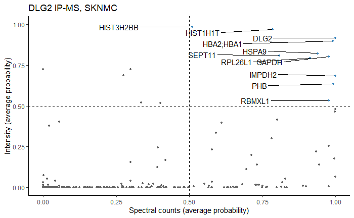

```r
###
spc = read_tsv(paste(baseRepository, '/proteomics20210726_dlg2IpmsEwsCells/reprintData_sknmcOnlySpc.tsv', sep = '')) %>%
  dplyr::select(PreyGene, AvgP, FDR) %>%
  dplyr::rename(gene = PreyGene, spc_avgP = AvgP, spc_fdr = FDR)
int = read_tsv(paste(baseRepository, '/proteomics20210726_dlg2IpmsEwsCells/reprintData_sknmcOnlyInt.tsv', sep = '')) %>%
  dplyr::select(PreyGene, AvgP, FDR) %>%
  dplyr::rename(gene = PreyGene, int_avgP = AvgP, int_fdr = FDR)
##
ipData = spc %>%
  left_join(int) %>%
  dplyr::mutate(pText = ifelse(spc_avgP >= 0.50 & int_avgP >= 0.50, gene, '')) %>%
  dplyr::mutate(pColor = ifelse(spc_avgP >= 0.50 & int_avgP >= 0.50, brewer.pal(3,'Blues')[3], brewer.pal(3,'Greys')[3]))
##
ggplot(ipData, aes(spc_avgP, int_avgP)) +
  geom_point(size = 1, color = ipData$pColor) +
  scale_x_continuous(limits = c(0,1), breaks = seq(0,1,0.25)) +
  scale_y_continuous(limits = c(0,1), breaks = seq(0,1,0.25)) +
  geom_text_repel(label = ipData$pText, nudge_x = -0.25, max.overlaps = 500) +
  labs(x = 'Spectral counts (average probability)', y = 'Intensity (average probability)', title = 'DLG2 IP-MS, SKNMC') +
  geom_hline(yintercept = 0.5, linetype = 'dashed') +
  geom_vline(xintercept = 0.5, linetype = 'dashed') +
  theme_classic()
ggsave(paste(baseRepository, '/proteomics20210726_dlg2IpmsEwsCells/scatter_dlg2IpmsSknmcOnlyPvalues.pdf',sep=''),
       height=2,width=2,useDingbats=FALSE)
```

Read in the ip data for all cells and plot.

```r
##########################################################################################
spc = read_tsv(paste(baseRepository, '/proteomics20210726_dlg2IpmsEwsCells/reprintData_allCellLinesSpc.tsv', sep = '')) %>%
  dplyr::select(PreyGene, AvgP, FDR) %>%
  dplyr::rename(gene = PreyGene, spc_avgP = AvgP, spc_fdr = FDR)
int = read_tsv(paste(baseRepository, '/proteomics20210726_dlg2IpmsEwsCells/reprintData_allCellLinesInt.tsv', sep = '')) %>%
  dplyr::select(PreyGene, AvgP, FDR) %>%
  dplyr::rename(gene = PreyGene, int_avgP = AvgP, int_fdr = FDR)

##
ipData = spc %>%
  left_join(int) %>%
  dplyr::mutate(pText = ifelse(spc_avgP >= 0.50 & int_avgP >= 0.50, gene, '')) %>%
  dplyr::mutate(pColor = ifelse(spc_avgP >= 0.50 & int_avgP >= 0.50, brewer.pal(3,'Blues')[3], brewer.pal(3,'Greys')[3]))

##
ggplot(ipData, aes(spc_avgP, int_avgP)) +
  geom_point(size = 1, color = ipData$pColor) +
  scale_x_continuous(limits = c(0,1), breaks = seq(0,1,0.25)) +
  scale_y_continuous(limits = c(0,1), breaks = seq(0,1,0.25)) +
  geom_text_repel(label = ipData$pText, nudge_x = -0.25, max.overlaps = 500) +
  labs(x = 'Spectral counts (average probability)', y = 'Intensity (average probability)', title = 'DLG2 IP-MS, all cells') +
  geom_hline(yintercept = 0.5, linetype = 'dashed') +
  geom_vline(xintercept = 0.5, linetype = 'dashed') +
  theme_classic()
ggsave(paste(baseRepository, '/proteomics20210726_dlg2IpmsEwsCells/scatter_dlg2IpmsAllCellLinesPvalues.pdf',sep=''),
       height=2,width=2,useDingbats=FALSE)
```

[output not shown]

What if we compare proteins ID’d from the SPC data in each of the individual cell lines.

```r
##
ipData = a673 %>%
  full_join(chla10) %>%
  full_join(sknmc)
```